Bruno Cossaro M1 DS

# Solving the 3D Linear Elasticity Equation with DeepXDE

## Problem description

The behavior of an elastic material under external forces is governed by the linear elasticity equations. These equations describe how the material deforms (displacements) in response to applied forces, based on its mechanical properties.

In the absence of body forces and assuming isotropic and homogeneous material properties, the equilibrium equations in 3D simplify to the **Poisson equation** for each component of the displacement vector $\mathbf{u} = (u, v, w)$:

$$ -\nabla^2 u = f_x(\mathbf{x}) $$

$$ -\nabla^2 v = f_y(\mathbf{x}) $$

$$ -\nabla^2 w = f_z(\mathbf{x}) $$

Where:

- $\nabla^2$ is the Laplacian operator, representing the sum of second derivatives with respect to spatial variables.
- $u, v, w$ are the displacement components in the $x$, $y$, and $z$ directions, respectively.
- $f_x, f_y, f_z$ are the components of the external force per unit volume.
- $\mathbf{x} = (x, y, z)$ represents the spatial coordinates within the domain.

## Problem setup

We consider a cubic domain $\Omega = [0, 1]^3$ with zero displacement on all boundaries (Dirichlet boundary conditions). This means the cube is fixed at its boundaries, and any deformation occurs within the interior due to the applied forces.

### Exact solution

To validate our numerical solution, we choose an exact analytical solution for the displacement components:

$$ u(\mathbf{x}) = \sin(\pi x) \sin(\pi y) \sin(\pi z) $$

$$ v(\mathbf{x}) = \sin(\pi x) \sin(\pi y) \sin(\pi z) $$

$$ w(\mathbf{x}) = \sin(\pi x) \sin(\pi y) \sin(\pi z) $$

From this exact solution, we can derive the corresponding source terms $f_x, f_y, f_z$ using the Laplacian:

$$ -\nabla^2 u = -\nabla^2 v = -\nabla^2 w = 3\pi^2 \sin(\pi x) \sin(\pi y) \sin(\pi z) $$

Thus, the source terms are:

$$ f_x(\mathbf{x}) = f_y(\mathbf{x}) = f_z(\mathbf{x}) = 3\pi^2 \sin(\pi x) \sin(\pi y) \sin(\pi z) $$

## Implementation in DeepXDE

To solve this problem using DeepXDE, will be needed to define the geometry, governing equations, boundary conditions, and the neural network architecture.

### Geometry definition

We define the cubic domain $\Omega$ using DeepXDE's geometry module:

```
import deepxde as dde

# Define the cubic domain
geom = dde.geometry.Cuboid([0, 0, 0], [1, 1, 1])
```

## Governing Equations

For each displacement component, we define a separate partial differential equation (PDE) corresponding to the Poisson equation:

For $u$:

$$ -\left( \frac{\partial^2 u}{\partial x^2} + \frac{\partial^2 u}{\partial y^2} + \frac{\partial^2 u}{\partial z^2} \right) = f_x(\mathbf{x}) $$

In DeepXDE, we implement this as:

```
def pde_u(x, u):
    u_xx = dde.grad.hessian(u, x, i=0, j=0)
    u_yy = dde.grad.hessian(u, x, i=1, j=1)
    u_zz = dde.grad.hessian(u, x, i=2, j=2)
    return -(u_xx + u_yy + u_zz) - f_component(x)
```

## Source Term Function

The source term $f_x(\mathbf{x})$ (similarly for $f_y$ and $f_z$) is defined using PyTorch functions to ensure compatibility with automatic differentiation of Deepxde, that facilitates the work of the library.

```
def f_component(x):
    return 3 * torch.pi**2 * torch.sin(torch.pi * x[:, 0:1]) * \
           torch.sin(torch.pi * x[:, 1:2]) * torch.sin(torch.pi * x[:, 2:3])
```

## Boundary Conditions

We apply Dirichlet boundary conditions, setting the displacement to zero on all boundaries:

```
def boundary(x, on_boundary):
    return on_boundary

bc_u = dde.DirichletBC(geom, lambda x: 0, boundary)
bc_v = dde.DirichletBC(geom, lambda x: 0, boundary)
bc_w = dde.DirichletBC(geom, lambda x: 0, boundary)
```

## Neural Network Architecture

We use a feedforward neural network with the following specifications:

- **Input dimension**: 3 (for $x$, $y$, $z$)
- **Output dimension**: 1 (displacement component)
- **Hidden layers**: 4 layers with 50 neurons each
- **Activation function**: Hyperbolic tangent ($\tanh$)
- **Initializer**: Glorot normal

The configuration is defined as follows:

```
layers = [3] + [50] * 4 + [1]
activation = "tanh"
initializer = "Glorot normal"

net_u = dde.maps.FNN(layers, activation, initializer)
net_v = dde.maps.FNN(layers, activation, initializer)
net_w = dde.maps.FNN(layers, activation, initializer)
```

## Model Compilation and Training

We create a `Model` object for each displacement component, compile it with the Adam optimizer, and train it:

[output not shown]

## Data Definition

The PDE object combines the geometry, the PDE, and the boundary conditions:

```
data_u = dde.data.PDE(
    geom,
    pde_u,
    bc_u,
    num_domain=10000,
    num_boundary=2000,
)

# Similarly for data_v and data_w

num_domain: Número de puntos de entrenamiento en el interior del dominio.
num_boundary: Número de puntos de entrenamiento en la frontera.
```

## Evaluation and Visualization of the Solution

After training, we evaluate the predictions of the neural network and compare them with the exact solution.

### Model Evaluation

We generate a set of points within the domain and compute the predicted and exact displacements:

```
X = geom.uniform_points(1000, True)
u_pred = model_u.predict(X)
u_exact = exact_solution(X)
```

### Relative $L^2$ Error Calculation

To quantify the accuracy of the predictions, we compute the relative $L^2$ error:

```
error_l2_u = dde.metrics.l2_relative_error(u_exact, u_pred)
```

```python
import deepxde as dde
import numpy as np
import matplotlib.pyplot as plt
import torch
import plotly.graph_objs as go
import plotly.io as pio

# Define the cubic geometry
gem = dde.geometry.Cuboid([0, 0, 0], [1, 1, 1])

# Exact solution function for validation
def exact_solution(x):
    return np.sin(np.pi * x[:, 0:1]) * np.sin(np.pi * x[:, 1:2]) * np.sin(np.pi * x[:, 2:3])

# Define the components of the source function f_x, f_y, f_z

def f_component(x):
    return 3 * torch.pi**2 * torch.sin(torch.pi * x[:, 0:1]) * torch.sin(torch.pi * x[:, 1:2]) * torch.sin(torch.pi * x[:, 2:3])

# Define the PDE for each component
def pde_u(x, u):
    u_xx = dde.grad.hessian(u, x, i=0, j=0)
    u_yy = dde.grad.hessian(u, x, i=1, j=1)
    u_zz = dde.grad.hessian(u, x, i=2, j=2)
    return -(u_xx + u_yy + u_zz) - f_component(x)

def pde_v(x, v):
    v_xx = dde.grad.hessian(v, x, i=0, j=0)
    v_yy = dde.grad.hessian(v, x, i=1, j=1)
    v_zz = dde.grad.hessian(v, x, i=2, j=2)
    return -(v_xx + v_yy + v_zz) - f_component(x)

def pde_w(x, w):
    w_xx = dde.grad.hessian(w, x, i=0, j=0)
    w_yy = dde.grad.hessian(w, x, i=1, j=1)
    w_zz = dde.grad.hessian(w, x, i=2, j=2)
    return -(w_xx + w_yy + w_zz) - f_component(x)

# Define the Dirichlet boundary conditions (u=0, v=0, w=0 on the boundary)
def boundary(x, on_boundary):
    return on_boundary

bc_u = dde.DirichletBC(geom, lambda x: 0, boundary)
bc_v = dde.DirichletBC(geom, lambda x: 0, boundary)
bc_w = dde.DirichletBC(geom, lambda x: 0, boundary)

# Define the problem data for each component
data_u = dde.data.PDE(
    geom,
    pde_u,
    bc_u,
    num_domain=10000,
    num_boundary=2000,
)

data_v = dde.data.PDE(
    geom,
    pde_v,
    bc_v,
    num_domain=10000,
    num_boundary=2000,
)

data_w = dde.data.PDE(
    geom,
    pde_w,
    bc_w,
    num_domain=10000,
    num_boundary=2000,
)
```

```
Using backend: pytorch
Other supported backends: tensorflow.compat.v1, tensorflow, jax, paddle.
paddle supports more examples now and is recommended.
```

```python
# Restore the trained models
model_u.restore('trained_model_u.ckpt')
model_v.restore('trained_model_v.ckpt')
model_w.restore('trained_model_w.ckpt')
```

```
Compiling model...
'compile' took 0.548397 s

Compiling model...
'compile' took 0.000089 s

Compiling model...
'compile' took 0.000070 s

Training model...

Step      Train loss              Test loss               Test metric
0         [9.38e+01, 2.95e-02]    [9.38e+01, 2.95e-02]    []
1000      [2.00e-02, 5.40e-03]    [2.00e-02, 5.40e-03]    []
2000      [5.50e-03, 3.18e-03]    [5.50e-03, 3.18e-03]    []
3000      [2.81e-03, 2.25e-03]    [2.81e-03, 2.25e-03]    []
4000      [3.47e-02, 1.71e-03]    [3.47e-02, 1.71e-03]    []
5000      [1.79e-03, 1.43e-03]    [1.79e-03, 1.43e-03]    []
6000      [1.14e-03, 1.19e-03]    [1.14e-03, 1.19e-03]    []
7000      [9.43e-04, 1.02e-03]    [9.43e-04, 1.02e-03]    []
8000      [1.24e-02, 8.65e-04]    [1.24e-02, 8.65e-04]    []
9000      [1.65e-02, 7.67e-04]    [1.65e-02, 7.67e-04]    []
10000     [1.01e-03, 7.18e-04]    [1.01e-03, 7.18e-04]    []

Best model at step 10000:
  train loss: 1.73e-03
  test loss: 1.73e-03
  test metric: []

'train' took 2818.349979 s

Training model...

Step      Train loss              Test loss               Test metric
0         [9.29e+01, 4.58e-02]    [9.29e+01, 4.58e-02]    []
1000      [7.50e-02, 6.05e-03]    [7.50e-02, 6.05e-03]    []
2000      [5.91e-03, 4.01e-03]    [5.91e-03, 4.01e-03]    []
3000      [1.11e-02, 2.80e-03]    [1.11e-02, 2.80e-03]    []
4000      [1.26e-02, 2.21e-03]    [1.26e-02, 2.21e-03]    []
5000      [1.41e-03, 1.81e-03]    [1.41e-03, 1.81e-03]    []
```

[output cut: 23 more lines]

```
7000      [1.88e-03, 9.87e-04]    [1.88e-03, 9.87e-04]    []
8000      [8.72e-04, 8.49e-04]    [8.72e-04, 8.49e-04]    []
9000      [1.19e-03, 7.75e-04]    [1.19e-03, 7.75e-04]    []
10000     [7.83e-04, 6.74e-04]    [7.83e-04, 6.74e-04]    []

Best model at step 10000:
  train loss: 1.46e-03
  test loss: 1.46e-03
  test metric: []

'train' took 4190.349137 s

Saving loss history to /Users/brunocossaro/loss.dat ...
Saving training data to /Users/brunocossaro/train.dat ...
Saving test data to /Users/brunocossaro/test.dat ...
```

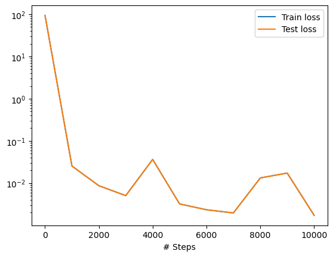

```
Saving loss history to /Users/brunocossaro/loss.dat ...
Saving training data to /Users/brunocossaro/train.dat ...
Saving test data to /Users/brunocossaro/test.dat ...
```

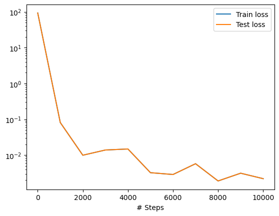

```
Saving loss history to /Users/brunocossaro/loss.dat ...
Saving training data to /Users/brunocossaro/train.dat ...
Saving test data to /Users/brunocossaro/test.dat ...
```

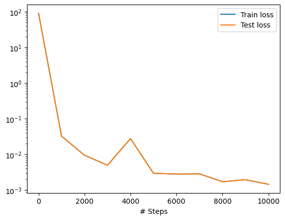

```python
# Archtecture of the neuronal network:
layers = [3] + [50] * 4 + [1]  # 3 entradas (x, y, z), 4 capas ocultas de 50 neuronas, 1 salida

activation = "tanh"
initializer = "Glorot normal"

# create neural network for each component
net_u = dde.maps.FNN(layers, activation, initializer)
net_v = dde.maps.FNN(layers, activation, initializer)
net_w = dde.maps.FNN(layers, activation, initializer)

# Create models for each component
model_u = dde.Model(data_u, net_u)
model_v = dde.Model(data_v, net_v)
model_w = dde.Model(data_w, net_w)

# Compile the models:
model_u.compile("adam", lr=1e-3)
model_v.compile("adam", lr=1e-3)
model_w.compile("adam", lr=1e-3)

# Training
losshistory_u, train_state_u = model_u.train(iterations=10000)
losshistory_v, train_state_v = model_v.train(iterations=10000)
losshistory_w, train_state_w = model_w.train(iterations=10000)

# Save and plot the loss
dde.saveplot(losshistory_u, train_state_u, issave=True, isplot=True)
dde.saveplot(losshistory_v, train_state_v, issave=True, isplot=True)
dde.saveplot(losshistory_w, train_state_w, issave=True, isplot=True)
```

```python
# After training the models
model_u.save('trained_model_u.ckpt')
model_v.save('trained_model_v.ckpt')
model_w.save('trained_model_w.ckpt')
```

```
'trained_model_w.ckpt-10000.pt'
```

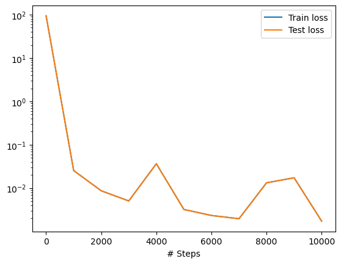

```python
#Convergence of each variable

# Para el modelo_u
dde.utils.plot_loss_history(losshistory_u)
plt.show()
```

```python
#Evaluate soluton:

# I create points for evaluation
X = geom.uniform_points(1000, True)

X_tensor = torch.from_numpy(X)
u_exact = exact_solution(X_tensor)

# Predicte the solution
u_pred = model_u.predict(X)
v_pred = model_v.predict(X)
w_pred = model_w.predict(X)

# Exact solution
u_exact = exact_solution(X)
v_exact = exact_solution(X)
w_exact = exact_solution(X)

# Magnitude of deplacements (desplazamientos)
displacements = np.hstack([u_pred, v_pred, w_pred])  #
disp_mag = np.linalg.norm(displacements, axis=1)


# Compute relative L2 error
error_l2_u = dde.metrics.l2_relative_error(u_exact, u_pred)
error_l2_v = dde.metrics.l2_relative_error(v_exact, v_pred)
error_l2_w = dde.metrics.l2_relative_error(w_exact, w_pred)

print(f"L2 relative error u: {error_l2_u:.3e}")
print(f"L2 relative error  v: {error_l2_v:.3e}")
print(f"L2 relative error  w: {error_l2_w:.3e}")
```

```
L2 relative error u: 7.650e-02
L2 relative error  v: 8.606e-02
L2 relative error  w: 7.212e-02
```

# Visualization

## Complete 3D Deformation Visualization

```python
import numpy as np
import plotly.graph_objs as go
from scipy.interpolate import griddata

# Number of points per side of the cube
n = 20

# Function to generate surface points of the cube

def generate_cube_surface_points(n):

    lin = np.linspace(0, 1, n)

    # Create a meshgrid from the linearly spaced array for X and Y coordinates
    X, Y = np.meshgrid(lin, lin)

    # Flatten the meshgrid arrays to make them one-dimensional
    X = X.flatten()
    Y = Y.flatten()


    faces = []

    # Face where x = 0 (left face of the cube)
    faces.append(np.vstack([np.zeros_like(X), Y, X]).T)

    # Face where x = 1 (right face of the cube)
    faces.append(np.vstack([np.ones_like(X), Y, X]).T)

    # Face where y = 0 (front face of the cube)
    faces.append(np.vstack([X, np.zeros_like(Y), Y]).T)

    # Face where y = 1 (back face of the cube)
    faces.append(np.vstack([X, np.ones_like(Y), Y]).T)

    # Face where z = 0 (bottom face of the cube)
    faces.append(np.vstack([X, Y, np.zeros_like(X)]).T)

    # Face where z = 1 (top face of the cube)
    faces.append(np.vstack([X, Y, np.ones_like(X)]).T)

    # Combine all the faces into a single array of surface points
    surface_points = np.concatenate(faces, axis=0)

    return surface_points

# Generate surface points of the cube
surface_points = generate_cube_surface_points(n)

# Predict displacements using the trained models

u_pred_surface = model_u.predict(surface_points)
v_pred_surface = model_v.predict(surface_points)
w_pred_surface = model_w.predict(surface_points)

# Calculate the new positions of the surface points after deformation
# Add the predicted displacements to the original surface points
deformed_points = surface_points + np.hstack([u_pred_surface, v_pred_surface, w_pred_surface])

# Calculate the magnitude of displacement at each surface point
# This will help in coloring the deformed cube based on how much it has moved
displacement_magnitude = np.linalg.norm(np.hstack([u_pred_surface, v_pred_surface, w_pred_surface]), axis=1)

# Split the deformed and original points into their respective cube faces
num_faces = 6
deformed_faces = np.split(deformed_points, num_faces)
original_faces = np.split(surface_points, num_faces)
displacement_faces = np.split(displacement_magnitude, num_faces)

# Create surfaces for the original cube with a neutral color (grey)
original_surfaces = []
for face in original_faces:
    # Extract x, y, z coordinates for the current face
    x, y, z = face[:, 0], face[:, 1], face[:, 2]

    # Reshape the coordinates to form a grid for plotting
    face_x = x.reshape(n, n)
    face_y = y.reshape(n, n)
    face_z = z.reshape(n, n)

    # Create a Plotly Surface object for the original face
    surface = go.Surface(
        x=face_x,
        y=face_y,
        z=face_z,
        colorscale='greys',          # Use grey color scale for the original cube
        showscale=False,             # Do not show the color scale for the original cube
        opacity=0.5,                 # Make the original cube semi-transparent
        name='Original'              # Name of the surface (useful for legends)
    )
    original_surfaces.append(surface)

# Create surfaces for the deformed cube with colors based on displacement magnitude
deformed_surfaces = []
for face, disp in zip(deformed_faces, displacement_faces):
    # Extract x, y, z coordinates for the deformed face
    x, y, z = face[:, 0], face[:, 1], face[:, 2]

    # Reshape the coordinates to form a grid for plotting
    face_x = x.reshape(n, n)
    face_y = y.reshape(n, n)
    face_z = z.reshape(n, n)

    # Reshape the displacement magnitudes to match the grid
    disp_grid = disp.reshape(n, n)

    # Create a Plotly Surface object for the deformed face
    surface = go.Surface(
        x=face_x,
        y=face_y,
        z=face_z,
        surfacecolor=disp_grid,               # Color the surface based on displacement magnitude
        colorscale='Viridis',                 # Use Viridis color scale for the deformed cube
        colorbar=dict(title='Displacement Magnitude'),  # Add a color bar with a title
        showscale=True,                       # Show the color scale for the deformed cube
        opacity=0.8,                           # Make the deformed cube slightly more opaque
        name='Deformed'                        # Name of the surface (useful for legends)
    )
    deformed_surfaces.append(surface)

# Combine all the surfaces (original and deformed) into a single list for plotting
data = original_surfaces + deformed_surfaces

# Configure the layout of the Plotly figure
layout = go.Layout(
    title='Cube Deformation: Original vs Deformed',  # Title of the plot
    scene=dict(
        xaxis=dict(title='X'),  # Labels
        yaxis=dict(title='Y'),
        zaxis=dict(title='Z'),
        aspectmode='data'       # Keep the aspect ratio consistent
    ),
    legend=dict(x=0, y=1)  # Position of the legend
)

fig = go.Figure(data=data, layout=layout)


fig.add_trace(go.Scatter3d(
    x=[None],
    y=[None],
    z=[None],
    mode='markers',
    marker=dict(size=0.1, color='grey'),
    name='Original'
))

fig.add_trace(go.Scatter3d(
    x=[None],
    y=[None],
    z=[None],
    mode='markers',
    marker=dict(size=0.1, color='blue'),
    name='Deformed'
))


fig.show(renderer="notebook_connected")
```

[interactive chart not shown]